# A report on student benchmark reaction times according to self-reported physical activity

This document was last run on 2023-09-28 and is a testament to the seamless synergy of Rmarkdown and Google Forms, working in perfect harmony to create a dynamic and easily updatable masterpiece.

Here we’ve crafted a document that updates effortlessly as new information is provided.

Whenever new information is collected by our form https://forms.gle/nLmLj37F6BCw8ygM8 this code behind this report can be run with a single button-push to update the document. This small analytical project also demonstrates an unbroken chain between raw data and published report.

## The relationship between Physical Activity and Reaction times

In the figure we have asked students to complete the Human Benchmark reaction times test three times - and self-report this alongside their own estimate of average daily physical activity:

- Is there any apparent relationship between self-reported activity and reaction speed?
- Are there any flaws or caveats to the trust we have in this data?
- Any other observations?

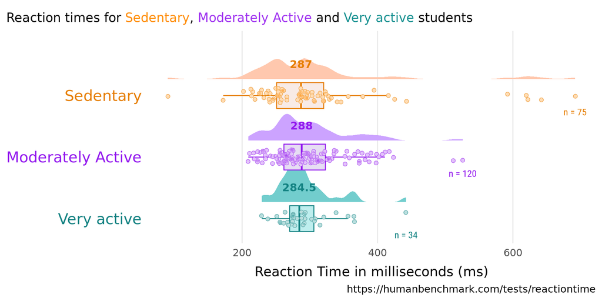

## The relationship between “Handedness” and Reaction times

In the figure we have asked students to complete the Human Benchmark reaction times test three times - and self-report this alongside which hand they consider dominant:

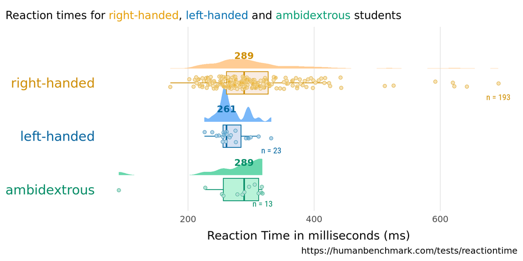